# Nonlinear Regression (Archontoulis and Miguez) paper

Fernando Miguez

2023-12-02

# Introduction

The **nlraa** is distributed as part of publications that illustrates the fit of nonlinear regression models.

## Example

We start by looking at biomass accumulation data from an experiment conducted in Greece by Danalatos and Archontoulis.

```r
data(sm)
str(sm)
```

```
## 'data.frame':    236 obs. of  5 variables:
##  $ DOY  : int  141 141 141 141 141 141 141 141 141 141 ...
##  $ Block: int  1 2 3 4 1 2 3 4 1 2 ...
##  $ Input: int  2 2 2 2 1 1 1 1 2 2 ...
##  $ Crop : Factor w/ 3 levels "F","M","S": 2 2 2 2 2 2 2 2 3 3 ...
##  $ Yield: num  0 0 0 0 0 0 0 0 0 0 ...
```

```r
head(sm)
```

```
##   DOY Block Input Crop Yield
## 1 141     1     2    M     0
## 2 141     2     2    M     0
## 3 141     3     2    M     0
## 4 141     4     2    M     0
## 5 141     1     1    M     0
## 6 141     2     1    M     0
```

The data represents Yield as harvested biomass for three crops: maize (M), fiber sorghum (F) and sweet sorghum (S).

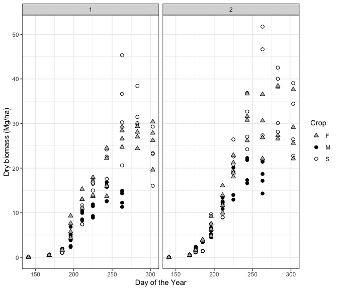

Before starting with the model fit we need to manipulate the data by creating an index which describes the experimental unit (eu). We also delete the DOY 141 when crops where planted.

```r
sm$eu <- with(sm, factor(Block):factor(Input):factor(Crop))
sm2 <- subset(sm, DOY != 141)
```

The next step is to create the **groupedData** which is a convenient structre to be used throughout the fitting process in **nlme**.

```r
smG <- groupedData(Yield ~ DOY | eu, data = sm2)
```

Originally, Danalatos et al. (2009) fitted the beta growth function as described by Yin et al. (2003). In **nlraa** we provide the **selfStart** function **SSbgf** to improve the fitting process.

```r
fit.lis <- nlsList(Yield ~ SSbgf(DOY, w.max, t.e, t.m), data = smG)
## But this works better
## Added 2020/1/2
fit.lis.rp <- nlsList(Yield ~ SSbgrp(DOY, w.max, lt.e, ldt), data = smG)
```

There are three crops, two levels of agronomic input and four blocks which results in 24 possible combinations. We fitted the model to these 24 experimental units and obtained apparent convergence in 20 (Note: was only 10 in the original paper, but this improved dramatically when I recomputed the partial derivatives 2020/1/3). Still, this suggests that some modifications are needed.

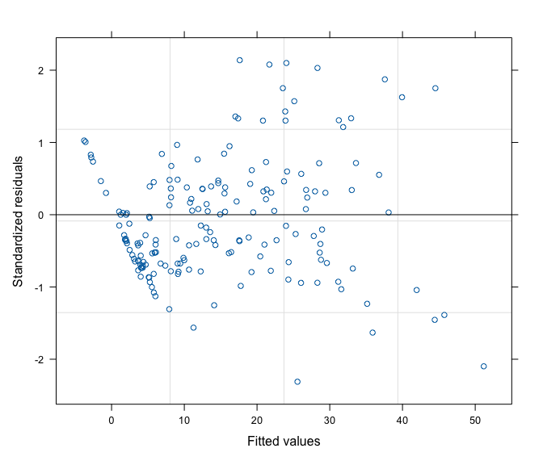

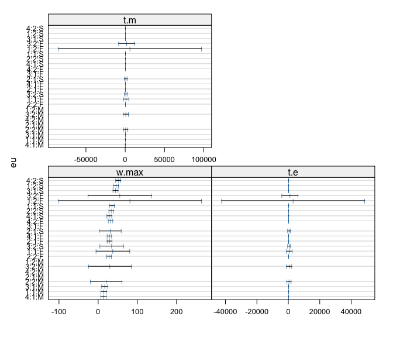

From the residuals plot we see some evidence of the inadequacy of the model. In particular the model over predicts at low values. We relax the convergence criteria to achieve a fitted model.

```r
fit.me <- nlme(fit.lis, control = list(maxIter = 100, msMaxIter = 300, pnlsMaxIter = 20))
```

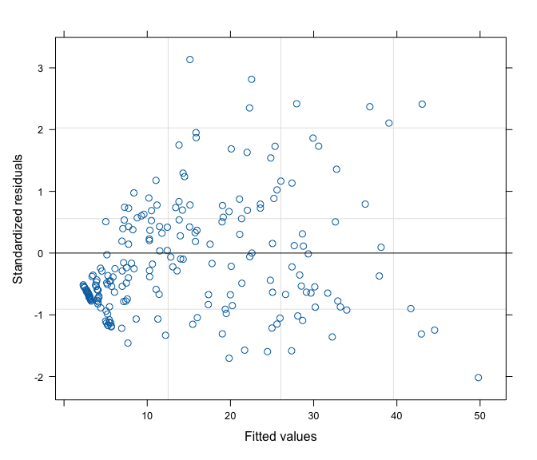

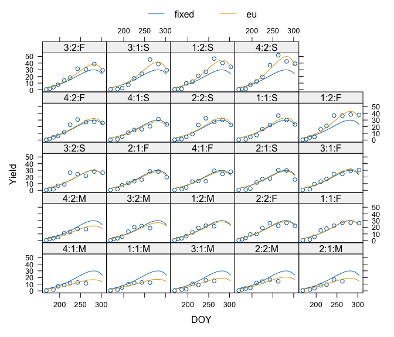

A modified beta growth function proposed by Yin et. al (2003) – included in the errata – allows for a delayed start of growth by modifying the $t_b$ parameter.

$$y = w_b + (w_{max} - w_b) \left (1 + \frac{t_e - t}{t_e - t_m} \right )
\left (\frac{t - t_b}{t_e - t_b} \right )^\frac{t_e - t_b}{t_e - t_m}$$

$$t_b < t_m < t_e$$

We include this as **bgf2** but not the selfStart version at this point. We also fix the $w_b$ and the $t_b$ parameters, so they are not part of the fitting process. There are good reasons for this: We know the initial biomass is minimal (seed weight) and we know the day of planting (it does not need to be optimized).

```r
fit.lis2 <- nlsList(Yield ~ bgf2(DOY, w.max, w.b = 0, t.e, t.m, t.b = 141),
                    data = smG,
                    start = c(w.max = 30, t.e=280, t.m=240))
```

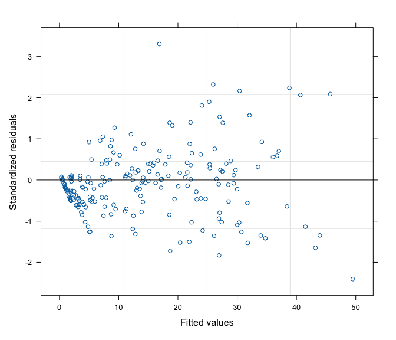

The previous figure shows a much lower bias at lower values.